# Planejamento e Análise de Experimentos I

Computacional

Author

Affiliation

[Prof. Dr. Juliano Bortolini](http://www.julianobortolini.com.br)

Universidade Federal de Mato Grosso

*Bacharelado em Estatística - UFMT*

# Análise de experimentos no R

```r
# Instalar pacotes, se não estiver instalado:
# install.packages("ExpDes")
# install.packages("lmtest")
# install.packages("MASS")
# install.packages("readxl")

# Carregar os pacotes:
library(ExpDes)
library(lmtest)
library(MASS)
library(readxl)
```

## Delineamento inteiramente casualizado

Modelo estatístico:

$$Y_{ij} = \mu + \tau_i + \epsilon_{ij},$$
em que $Y_{ij}$ é a observação referente ao tratamento $i$ e repetição $j$, $i = 1, \cdots, I$, $j = 1, \cdots, J$, $\mu$ é uma constante comum a todas as observações, $\tau_i$ é o efeito do tratamento $i$ e $\epsilon_{ij}$ é o erro experimental, que se supõe que seja independente e identicamente distribuído (normal) com média zero e variância $\sigma^2$.

### Experimento

1. Um experimento foi conduzido no **delineamento inteiramente casualizado (DIC)**, com **quatro repetições**, para avaliar a altura de plantas da espécie florestal **acácia** (*Acacia holocericea*) submetidas a diferentes substratos para formação de mudas. Os tratamentos e os valores de altura de planta (em cm) foram registrados na seguinte tabela:

| Substratos | Rep. 1 | Rep. 2 | Rep. 3 | Rep. 4 |
| --- | --- | --- | --- | --- |
| CaC+EB | 18,2 | 16,4 | 20,5 | 19,4 |
| CaC+EA | 12,8 | 14,5 | 10,3 | 11,5 |
| HM | 21,8 | 19,3 | 24,5 | 22,6 |
| Cap+EA | 14,8 | 16,4 | 12,3 | 13,7 |
| Cap+EB | 13,0 | 11,2 | 15,4 | 12,6 |
| Plantmax | 16,0 | 14,2 | 18,1 | 16,4 |

Realize a análise de variância com comparações múltiplas de Tukey, considerando um nível de significância de $5\%$.

Arquivo com os dados: dados_1.xlsx

```r
# Lendo os dados
dados_1 <- read_xlsx("dados_1.xlsx")
dados_1
```

```
# A tibble: 24 × 3
   repeticao substratos altura
       <dbl> <chr>       <dbl>
 1         1 CaC+EB       18.2
 2         2 CaC+EB       16.4
 3         3 CaC+EB       20.5
 4         4 CaC+EB       19.4
 5         1 CaC+EA       12.8
 6         2 CaC+EA       14.5
 7         3 CaC+EA       10.3
 8         4 CaC+EA       11.5
 9         1 HM           21.8
10         2 HM           19.3
# ℹ 14 more rows
```

```r
names(dados_1)
```

```
[1] "repeticao"  "substratos" "altura"
```

```r
# Anova usando a função lm do pacote stats
# A função lm é a função padrão para ajuste de modelos lineares no R

# A variável com os tratamentos precisa ser fator
dados_1$substratos <- as.factor(dados_1$substratos)

# definindo o modelo linear
lm_dic <- lm(altura ~ substratos, data = dados_1)

# estimativas dos parâmetros do modelo linear
summary(lm_dic)
```

```
Call:
lm(formula = altura ~ substratos, data = dados_1)

Residuals:
    Min      1Q  Median      3Q     Max
-2.7500 -1.0437 -0.1125  1.0500  2.4500

Coefficients:
                   Estimate Std. Error t value Pr(>|t|)
(Intercept)         12.2750     0.9034  13.587 6.66e-11 ***
substratosCaC+EB     6.3500     1.2776   4.970 9.90e-05 ***
substratosCap+EA     2.0250     1.2776   1.585  0.13038
substratosCap+EB     0.7750     1.2776   0.607  0.55169
substratosHM         9.7750     1.2776   7.651 4.60e-07 ***
substratosPlantmax   3.9000     1.2776   3.053  0.00685 **
---
Signif. codes:  0 '***' 0.001 '**' 0.01 '*' 0.05 '.' 0.1 ' ' 1

Residual standard error: 1.807 on 18 degrees of freedom
Multiple R-squared:  0.8244,    Adjusted R-squared:  0.7756
F-statistic:  16.9 on 5 and 18 DF,  p-value: 3.03e-06
```

```r
# Análise de variância
anova(lm_dic)
```

```
Analysis of Variance Table

Response: altura
           Df  Sum Sq Mean Sq F value   Pr(>F)
substratos  5 275.817  55.163  16.898 3.03e-06 ***
Residuals  18  58.762   3.265
---
Signif. codes:  0 '***' 0.001 '**' 0.01 '*' 0.05 '.' 0.1 ' ' 1
```

```r
# ANOVA usando ExpDes
# teste Tukey é o padrão para comparações múltiplas
crd(treat = dados_1$substratos,
    resp = dados_1$altura)
```

```
------------------------------------------------------------------------
Analysis of Variance Table
------------------------------------------------------------------------
           DF     SS     MS     Fc      Pr>Fc
Treatament  5 275.82 55.163 16.898 3.0304e-06
Residuals  18  58.76  3.265
Total      23 334.58
------------------------------------------------------------------------
CV = 11.24 %

------------------------------------------------------------------------
Shapiro-Wilk normality test
p-value:  0.1502373
According to Shapiro-Wilk normality test at 5% of significance, residuals can be considered normal.
------------------------------------------------------------------------

------------------------------------------------------------------------
Homogeneity of variances test
p-value:  0.9980527
According to the test of bartlett at 5% of significance, residuals can be considered homocedastic.
------------------------------------------------------------------------

Tukey's test
------------------------------------------------------------------------
Groups Treatments Means
a    HM      22.05
ab   CaC+EB      18.625
 bc      Plantmax    16.175
  c      Cap+EA      14.3
  c      Cap+EB      13.05
  c      CaC+EA      12.275
------------------------------------------------------------------------
```

Note que há ambiguidade no teste de comparações múltipla usando o teste de Tukey. Uma outra opção para as comparações múltiplas é usar o teste Scott-Knott.

```r
# teste Scott-knott:
crd(treat = dados_1$substratos,
    resp = dados_1$altura,
    mcomp = "sk")
```

```
------------------------------------------------------------------------
Analysis of Variance Table
------------------------------------------------------------------------
           DF     SS     MS     Fc      Pr>Fc
Treatament  5 275.82 55.163 16.898 3.0304e-06
Residuals  18  58.76  3.265
Total      23 334.58
------------------------------------------------------------------------
CV = 11.24 %

------------------------------------------------------------------------
Shapiro-Wilk normality test
p-value:  0.1502373
According to Shapiro-Wilk normality test at 5% of significance, residuals can be considered normal.
------------------------------------------------------------------------

------------------------------------------------------------------------
Homogeneity of variances test
p-value:  0.9980527
According to the test of bartlett at 5% of significance, residuals can be considered homocedastic.
------------------------------------------------------------------------

Scott-Knott test
------------------------------------------------------------------------
  Groups Treatments  Means
1      a         HM 22.050
2      b     CaC+EB 18.625
3      c   Plantmax 16.175
4      c     Cap+EA 14.300
5      c     Cap+EB 13.050
6      c     CaC+EA 12.275
------------------------------------------------------------------------
```

Outras opções de teste de comparações múltiplas:

```r
# ?crd
# mcomp
# Allows choosing the multiple comparison test; the default is the test of Tukey, however, the options are: the LSD test ('lsd'), the LSD test with Bonferroni protection ('lsdb'), the test of Duncan ('duncan'), the test of Student-Newman-Keuls ('snk'), the test of Scott-Knot ('sk'), the Calinski and Corsten test ('ccF') and bootstrap multiple comparison's test ('ccboot').
```

## Delineamento em blocos casualizados

Modelo estatístico:

$$Y_{ij} = \mu + \tau_i + \beta_j + \epsilon_{ij},$$
em que $Y_{ij}$ é a observação referente ao tratamento $i$ e bloco $j$, $i = 1, \cdots, I$, $j = 1, \cdots, J$, $\mu$ é uma constante comum a todas as observações, $\tau_i$ é o efeito do tratamento $i$, $\beta_j$ é o efeito do bloco $j$ e $\epsilon_{ij}$ é o erro experimental, que se supõe que seja independente e identicamente distribuído (normal) com média zero e variância $\sigma^2$.

### Experimento

2. Os dados da Tabela 1 referem-se a um ensaio sobre a influência de quatro épocas de corte na produtividade de matéria verde de uma variedade de alfafa. As épocas estudadas foram $A$, $B$, $C$ e $D$, sendo $A$ a mais precoce e $D$ a mais tardia. Foi utilizado o delineamento em Blocos Casualizados para controlar um possível gradiente de fertilidade do solo, já que a área experimental apresentava uma declividade de $12\%$.

**Tabela 1**: Produções em $\text{Kg/parcela}$ de matéria verde de alfafa.

| Blocos | $A$ | $B$ | $C$ | $D$ |
| --- | --- | --- | --- | --- |
| $I$ | 2,89 | 1,58 | 2,29 | 2,56 |
| $II$ | 2,88 | 1,28 | 2,98 | 2,00 |
| $III$ | 1,88 | 1,22 | 1,55 | 1,82 |
| $IV$ | 2,90 | 1,21 | 1,95 | 2,20 |
| $V$ | 2,20 | 1,30 | 1,15 | 1,33 |
| $VI$ | 2,65 | 1,66 | 1,12 | 1,00 |

Realize a análise de variância com teste Tukey para comparações múltiplas, ao nível de $5\%$ de probabilidade.

Arquivo com os dados: dados_2.xlsx

```r
# Lendo os dados
dados_2 <- read_xlsx("dados_2.xlsx")
dados_2
```

```
# A tibble: 24 × 3
   bloco epoca produtividade
   <dbl> <chr>         <dbl>
 1     1 A              2.89
 2     1 B              1.58
 3     1 C              2.29
 4     1 D              2.56
 5     2 A              2.88
 6     2 B              1.28
 7     2 C              2.98
 8     2 D              2
 9     3 A              1.88
10     3 B              1.22
# ℹ 14 more rows
```

```r
names(dados_2)
```

```
[1] "bloco"         "epoca"         "produtividade"
```

```r
# Anova usando a função lm do pacote stats

# As variáveis com os blocos e tratamentos precisam ser fator
dados_2$bloco <- as.factor(dados_2$bloco)
dados_2$epoca <- as.factor(dados_2$epoca)

# definindo o modelo linear
lm_dbc <- lm(produtividade ~ bloco + epoca, data = dados_2)

# estimativas dos parâmetros do modelo linear
summary(lm_dbc)
```

```
Call:
lm(formula = produtividade ~ bloco + epoca, data = dados_2)

Residuals:
     Min       1Q   Median       3Q      Max
-0.52583 -0.24000 -0.03125  0.23354  0.75500

Coefficients:
            Estimate Std. Error t value Pr(>|t|)
(Intercept)   2.9967     0.2543  11.784 5.54e-09 ***
bloco2       -0.0450     0.2936  -0.153 0.880242
bloco3       -0.7125     0.2936  -2.426 0.028318 *
bloco4       -0.2650     0.2936  -0.902 0.381063
bloco5       -0.8350     0.2936  -2.844 0.012323 *
bloco6       -0.7225     0.2936  -2.461 0.026486 *
epocaB       -1.1917     0.2397  -4.970 0.000168 ***
epocaC       -0.7267     0.2397  -3.031 0.008425 **
epocaD       -0.7483     0.2397  -3.121 0.007006 **
---
Signif. codes:  0 '***' 0.001 '**' 0.01 '*' 0.05 '.' 0.1 ' ' 1

Residual standard error: 0.4153 on 15 degrees of freedom
Multiple R-squared:  0.7341,    Adjusted R-squared:  0.5923
F-statistic: 5.176 on 8 and 15 DF,  p-value: 0.003083
```

```r
# Análise de variância
anova(lm_dbc)
```

```
Analysis of Variance Table

Response: produtividade
          Df Sum Sq Mean Sq F value   Pr(>F)
bloco      5 2.7590 0.55179  3.1999 0.036559 *
epoca      3 4.3820 1.46068  8.4706 0.001572 **
Residuals 15 2.5866 0.17244
---
Signif. codes:  0 '***' 0.001 '**' 0.01 '*' 0.05 '.' 0.1 ' ' 1
```

```r
# ANOVA usando ExpDes
# teste Tukey é o padrão para comparações múltiplas
rbd(treat = dados_2$epoca,
    block = dados_2$bloco,
    resp = dados_2$produtividade)
```

```
------------------------------------------------------------------------
Analysis of Variance Table
------------------------------------------------------------------------
           DF     SS      MS     Fc    Pr>Fc
Treatament  3 4.3820 1.46068 8.4706 0.001572
Block       5 2.7590 0.55179 3.1999 0.036559
Residuals  15 2.5866 0.17244
Total      23 9.7276
------------------------------------------------------------------------
CV = 21.86 %

------------------------------------------------------------------------
Shapiro-Wilk normality test
p-value:  0.7947678
According to Shapiro-Wilk normality test at 5% of significance, residuals can be considered normal.
------------------------------------------------------------------------

------------------------------------------------------------------------
Homogeneity of variances test
p-value:  0.6274363
According to the test of oneillmathews at 5% of significance, the variances can be considered homocedastic.
------------------------------------------------------------------------

Tukey's test
------------------------------------------------------------------------
Groups Treatments Means
a    A   2.566667
 b   C   1.84
 b   D   1.818333
 b   B   1.375
------------------------------------------------------------------------
```

```r
# Anova com o teste Duncan para comparações múltiplas
rbd(treat = dados_2$epoca,
    block = dados_2$bloco,
    resp = dados_2$produtividade,
    mcomp = "duncan")
```

```
------------------------------------------------------------------------
Analysis of Variance Table
------------------------------------------------------------------------
           DF     SS      MS     Fc    Pr>Fc
Treatament  3 4.3820 1.46068 8.4706 0.001572
Block       5 2.7590 0.55179 3.1999 0.036559
Residuals  15 2.5866 0.17244
Total      23 9.7276
------------------------------------------------------------------------
CV = 21.86 %

------------------------------------------------------------------------
Shapiro-Wilk normality test
p-value:  0.7947678
According to Shapiro-Wilk normality test at 5% of significance, residuals can be considered normal.
------------------------------------------------------------------------

------------------------------------------------------------------------
Homogeneity of variances test
p-value:  0.6274363
According to the test of oneillmathews at 5% of significance, the variances can be considered homocedastic.
------------------------------------------------------------------------

Duncan's test
------------------------------------------------------------------------
Groups  Treatments  Means
a    A       2.566667
 b   C       1.84
 b   D       1.818333
 b   B       1.375
------------------------------------------------------------------------
```

## Delineamento em quadrado latino

Modelo estatístico:

$$Y_{ijk} = \mu + \tau_i + L_j + C_k + \epsilon_{ijk},$$
em que $Y_{ijk}$ é a observação referente ao tratamento $i$ na linha $j$ e coluna $k$, $i = 1, \cdots, p$, $j = 1, \cdots, p$, $k = 1, \cdots, p$, $\mu$ é uma constante comum a todas as observações, $\tau_i$ é o efeito do tratamento $i$, $L_j$ é o efeito da linha $j$, $C_k$ é o efeito da coluna $k$ e $\epsilon_{ijk}$ é o erro experimental, que se supõe que seja independente e identicamente distribuído (normal) com média zero e variância $\sigma^2$.

### Experimento

3. Um engenheiro aeroespacial está estudando os efeitos de cinco formulações diferentes de um propulsor de foguete usado em sistemas de evacuação da tripulação.
- Variável observada: velocidade de queima das formulações.
- Cada formulação é misturada a partir de um lote de matéria-prima suficiente para cinco formulações.
- As formulações são preparadas por diversos operadores.
- Duas fontes de perturbação: lotes e operadores.
- Delineamento apropriado: testar cada formulação apenas uma vez em cada lote de matéria-prima e cada operador preparar uma vez cada formulação.

**Tabela 2**: Velocidade de queima de diferentes formulações (A, B, C, D, E) para diferentes lotes de matéria-prima e operadores.

| Lote/Operador | 1 | 2 | 3 | 4 | 5 |
| --- | --- | --- | --- | --- | --- |
| 1 | A=24 | B=20 | C=19 | D=24 | E=24 |
| 2 | B=17 | C=24 | D=30 | E=27 | A=36 |
| 3 | C=18 | D=38 | E=26 | A=27 | B=21 |
| 4 | D=26 | E=31 | A=26 | B=23 | C=22 |
| 5 | E=22 | A=30 | B=20 | C=29 | D=31 |

Arquivo com os dados: dados_3.xlsx

```r
# Lendo os dados
dados_3 <- read_xlsx("dados_3.xlsx")
dados_3
```

```
# A tibble: 25 × 4
    lote operador formulacoes velocidade
   <dbl>    <dbl> <chr>            <dbl>
 1     1        1 A                   24
 2     2        1 B                   17
 3     3        1 C                   18
 4     4        1 D                   26
 5     5        1 E                   22
 6     1        2 B                   20
 7     2        2 C                   24
 8     3        2 D                   38
 9     4        2 E                   31
10     5        2 A                   30
# ℹ 15 more rows
```

```r
names(dados_3)
```

```
[1] "lote"        "operador"    "formulacoes" "velocidade"
```

```r
# Anova usando a função lm do pacote stats

# As variáveis com as linhas, colunas e tratamentos precisam ser fator
dados_3$lote <- as.factor(dados_3$lote)
dados_3$operador <- as.factor(dados_3$operador)
dados_3$formulacoes <- as.factor(dados_3$formulacoes)

# definindo o modelo linear
lm_dql <- lm(velocidade ~ lote + operador + formulacoes, data = dados_3)

# estimativas dos parâmetros do modelo linear
summary(lm_dql)
```

```
Call:
lm(formula = velocidade ~ lote + operador + formulacoes, data = dados_3)

Residuals:
   Min     1Q Median     3Q    Max
  -3.2   -1.2   -0.2    1.0    5.0

Coefficients:
             Estimate Std. Error t value Pr(>|t|)
(Intercept)    21.400      2.355   9.087 9.98e-07 ***
lote2           4.600      2.066   2.227  0.04586 *
lote3           3.800      2.066   1.840  0.09067 .
lote4           3.400      2.066   1.646  0.12568
lote5           4.200      2.066   2.033  0.06475 .
operador2       7.200      2.066   3.486  0.00450 **
operador3       2.800      2.066   1.356  0.20021
operador4       4.600      2.066   2.227  0.04586 *
operador5       5.400      2.066   2.614  0.02262 *
formulacoesB   -8.400      2.066  -4.067  0.00156 **
formulacoesC   -6.200      2.066  -3.002  0.01103 *
formulacoesD    1.200      2.066   0.581  0.57203
formulacoesE   -2.600      2.066  -1.259  0.23207
---
Signif. codes:  0 '***' 0.001 '**' 0.01 '*' 0.05 '.' 0.1 ' ' 1

Residual standard error: 3.266 on 12 degrees of freedom
Multiple R-squared:  0.8107,    Adjusted R-squared:  0.6213
F-statistic: 4.281 on 12 and 12 DF,  p-value: 0.008855
```

```r
# Análise de variância
anova(lm_dql)
```

```
Analysis of Variance Table

Response: velocidade
            Df Sum Sq Mean Sq F value   Pr(>F)
lote         4     68  17.000  1.5938 0.239059
operador     4    150  37.500  3.5156 0.040373 *
formulacoes  4    330  82.500  7.7344 0.002537 **
Residuals   12    128  10.667
---
Signif. codes:  0 '***' 0.001 '**' 0.01 '*' 0.05 '.' 0.1 ' ' 1
```

```r
# ANOVA usando ExpDes
# teste Tukey é o padrão para comparações múltiplas
latsd(treat = dados_3$formulacoes,
    row = dados_3$lote,
    column = dados_3$operador,
    resp = dados_3$velocidade)
```

```
------------------------------------------------------------------------
Analysis of Variance Table
------------------------------------------------------------------------
           DF  SS     MS     Fc    Pr>Fc
Treatament  4 330 82.500 7.7344 0.002537
Row         4  68 17.000 1.5938 0.239059
Column      4 150 37.500 3.5156 0.040373
Residuals  12 128 10.667
Total      24 676
------------------------------------------------------------------------
CV = 12.86 %

------------------------------------------------------------------------
Shapiro-Wilk normality test
p-value:  0.05810583
According to Shapiro-Wilk normality test at 5% of significance, residuals can be considered normal.
------------------------------------------------------------------------

Tukey's test
------------------------------------------------------------------------
Groups Treatments Means
a    D   29.8
ab   A   28.6
abc      E   26
 bc      C   22.4
  c      B   20.2
------------------------------------------------------------------------
```

## Análise de resíduos

Os pressupostos a serem verificados em uma análise de experimentos (anova) são: resíduos normais, independentes e de variância constante (homocedasticidade). Também é desejável verificar se há pontos discrepantes e a linearidade da variável resposta.

O **resíduo bruto**, ou simplesmente resíduo, é definido por:

$$\hat{\epsilon}_{ij} = Y_{ij} - \hat{Y}_{ij},$$

em que $Y_{ij}$ é o valor observado e $\hat{Y}_{ij}$ é o valor estimado pelo modelo.

```r
# Resíduo bruto
res_1 <- residuals(lm_dic)
res_1
```

```
     1      2      3      4      5      6      7      8      9     10     11
-0.425 -2.225  1.875  0.775  0.525  2.225 -1.975 -0.775 -0.250 -2.750  2.450
    12     13     14     15     16     17     18     19     20     21     22
 0.550  0.500  2.100 -2.000 -0.600 -0.050 -1.850  2.350 -0.450 -0.175 -1.975
    23     24
 1.925  0.225
```

```r
dados_1$altura - fitted(lm_dic)
```

```
     1      2      3      4      5      6      7      8      9     10     11
-0.425 -2.225  1.875  0.775  0.525  2.225 -1.975 -0.775 -0.250 -2.750  2.450
    12     13     14     15     16     17     18     19     20     21     22
 0.550  0.500  2.100 -2.000 -0.600 -0.050 -1.850  2.350 -0.450 -0.175 -1.975
    23     24
 1.925  0.225
```

O **resíduo padronizado** (**resíduo de Pearson**) é usado para facilitar a comparação entre diferentes observações:

$$d_{ij} = \frac{\hat{\epsilon}_{ij}}{\sqrt{\hat{\sigma}^2}},$$
em que $\hat{\sigma}^2 = QM_{Erro}$ é o quadrado médio do erro da análise de variância.

```r
# Resíduo padronizado (ou Pearson)
anova(lm_dic) # ANOVA
```

```
Analysis of Variance Table

Response: altura
           Df  Sum Sq Mean Sq F value   Pr(>F)
substratos  5 275.817  55.163  16.898 3.03e-06 ***
Residuals  18  58.762   3.265
---
Signif. codes:  0 '***' 0.001 '**' 0.01 '*' 0.05 '.' 0.1 ' ' 1
```

```r
sigma2 <- anova(lm_dic)[2,3] # quadrado médio do erro
sigma2
```

```
[1] 3.264583
```

```r
res_2 <- residuals(lm_dic) / sqrt(sigma2)
res_2
```

```
          1           2           3           4           5           6
-0.23522044 -1.23144816  1.03773722  0.42893138  0.29056642  1.23144816
          7           8           9          10          11          12
-1.09308320 -0.42893138 -0.13836496 -1.52201459  1.35597663  0.30440292
         13          14          15          16          17          18
 0.27672992  1.16226568 -1.10691970 -0.33207591 -0.02767299 -1.02390072
         19          20          21          22          23          24
 1.30063065 -0.24905693 -0.09685547 -1.09308320  1.06541021  0.12452847
```

É possível padronizar os resíduos considerando a variabilidade individual dos resíduos (alavancagem). Ele é calculado como:

$$r_{ij} = \frac{\hat{\epsilon}_{ij}}{\sqrt{\hat{\sigma}^2(1 - h_{ii})}},$$
em que $h_{ii}$ é o $i$-ésimo elemento da diagonal da matriz hat $H$

Esse resíduo possibilita uma identificação mais precisa de pontos influentes e discrepantes. **Esse resíduo também é comumente chamado de resíduo padronizado**. É mais comum chamar esse resíduo de padronizado ao invés do de Pearson! Outro nome possível para esse resíduos é studentizado internamente.

```r
# Resíduo padronizado (studentizado internamente)
res_3 <- rstandard(lm_dic)
res_3
```

```
          1           2           3           4           5           6
-0.27160916 -1.42195386  1.19827572  0.49528730  0.33551720  1.42195386
          7           8           9          10          11          12
-1.26218376 -0.49528730 -0.15977010 -1.75747106  1.56574695  0.35149421
         13          14          15          16          17          18
 0.31954019  1.34206881 -1.27816077 -0.38344823 -0.03195402 -1.18229871
         19          20          21          22          23          24
 1.50183891 -0.28758617 -0.11183907 -1.26218376  1.23022974  0.14379309
```

```r
# comparação entre os três tipos de resíduos para LM
data.frame(res_1, res_2, res_3)
```

```
    res_1       res_2       res_3
1  -0.425 -0.23522044 -0.27160916
2  -2.225 -1.23144816 -1.42195386
3   1.875  1.03773722  1.19827572
4   0.775  0.42893138  0.49528730
5   0.525  0.29056642  0.33551720
6   2.225  1.23144816  1.42195386
7  -1.975 -1.09308320 -1.26218376
8  -0.775 -0.42893138 -0.49528730
9  -0.250 -0.13836496 -0.15977010
10 -2.750 -1.52201459 -1.75747106
11  2.450  1.35597663  1.56574695
12  0.550  0.30440292  0.35149421
13  0.500  0.27672992  0.31954019
14  2.100  1.16226568  1.34206881
15 -2.000 -1.10691970 -1.27816077
16 -0.600 -0.33207591 -0.38344823
17 -0.050 -0.02767299 -0.03195402
18 -1.850 -1.02390072 -1.18229871
19  2.350  1.30063065  1.50183891
20 -0.450 -0.24905693 -0.28758617
21 -0.175 -0.09685547 -0.11183907
22 -1.975 -1.09308320 -1.26218376
23  1.925  1.06541021  1.23022974
24  0.225  0.12452847  0.14379309
```

### Normalidade dos resíduos

- **Histograma dos resíduos padronizados ($d_{ij}$ ou $r_{ij}$)**: Deve apresentar uma forma semelhante à curva normal padrão.

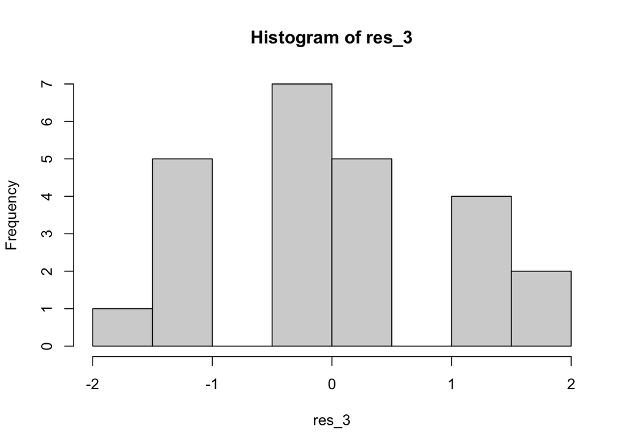

```r
# histograma dos resíduos
hist(res_3)
```

- **Gráfico dos valores estimados versus resíduos padronizados**: Deve apresentar pontos dispostos de forma aleatória, geralmente concentrados no intervalo $(-2, 2)$.

```r
# Gráfico dos valores estimados versus resíduos padronizados
y_est <- fitted(lm_dic)
plot(y_est, res_3) # os pontos estão entre (-2, 2)?
```

[output not shown]

- **Comparação de frequências**: Consiste em comparar a frequência relativa dos resíduos padronizados nos intervalos $(-1, 1)$, $(-1,64, 1,64)$ e $(-1,96, 1,96)$ com as probabilidades teóricas de 68%, 90% e 95%, respectivamente, da distribuição normal padrão.

```r
# comparação de frequências
intervalos <- c("-1 a 1", "-1.64 a 1.64", "-1.96 a 1.96")
frequencias_r <- c(mean(res_3 > -1 & res_3 < 1),
                 mean(res_3 > -1.64 & res_3 < 1.64),
                 mean(res_3 > -1.96 & res_3 < 1.96))
probabilidades <- c(0.68, 0.90, 0.95)
data.frame(intervalos, frequencias_r, probabilidades)
```

```
    intervalos frequencias_r probabilidades
1       -1 a 1     0.5000000           0.68
2 -1.64 a 1.64     0.9583333           0.90
3 -1.96 a 1.96     1.0000000           0.95
```

- **Gráfico quantil-quantil (Q-Q plot)**: Com os resíduos ordenados versus os quantis da distribuição normal padronizada, o gráfico deve aproximar-se da reta bissetriz, demonstrando a aderência à normalidade.

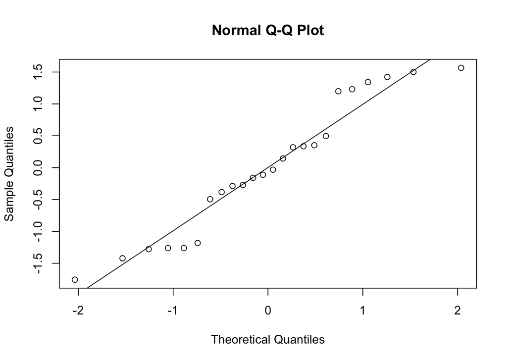

```r
# qq-plot
qqnorm(res_3)
qqline(res_3)
```

Além dessas abordagens visuais, a aplicação de testes de aderência (não-paramétricos) também pode ser realizada. Dentre esses, os mais conhecidos incluem:  
Qui-quadrado, **Kolmogorov-Smirnov**, Jarque-Bera, **Shapiro-Wilk**, Anderson-Darling, Cramér-von Mises, D’Agostino-Pearson, Lilliefors, e Shapiro-Francia.

```r
# Teste de Shapiro-Wilk
shapiro.test(res_3)
```

```
    Shapiro-Wilk normality test

data:  res_3
W = 0.9384, p-value = 0.1502
```

```r
# Teste de Kolmogorov-Smirnov
ks.test(res_3, "pnorm", mean = 0, sd = 1)
```

```
    Exact one-sample Kolmogorov-Smirnov test

data:  res_3
D = 0.1346, p-value = 0.728
alternative hypothesis: two-sided
```

### Independência dos Resíduos

Sem a informação sobre a ordem de execução dos experimentos, não é possível aplicar testes estatísticos para a independência que dependem de uma sequência temporal ou da coleta dos dados. Nesse caso, a inferência sobre a independência dos resíduos deve basear-se na robustez do desenho experimental - que, se bem realizado com aleatorização, repetição e controle local, sugere naturalmente a independência dos resíduos.

Alguns métodos para avaliar a independência incluem:

- **Gráfico dos valores estimados versus resíduos padronizados**: Os pontos devem estar distribuídos aleatoriamente, sem a formação de padrões específicos.

```r
# Gráfico dos valores estimados versus resíduos padronizados
plot(y_est, res_3)
```

[output not shown]

- **Gráfico da ordem de coleta dos dados versus resíduos padronizados**: Quando a ordem de coleta é conhecida, a ausência de padrões neste gráfico indica independência.
- **Função de autocorrelação**: Permite avaliar a correlação entre os resíduos em diferentes defasagens.
- **Testes estatísticos**: Entre os testes de independência, destaca-se o teste **Durbin-Watson**, além do teste de Breusch-Godfrey e Ljung-Box.

### Homocedasticidade dos Resíduos

A homocedasticidade refere-se à igualdade das variâncias dos resíduos para todos os tratamentos. Essa verificação pode ser feita por:

- **Gráfico dos valores estimados versus resíduos padronizados**: A ausência de padrão ou “funil” indica homogeneidade das variâncias.

```r
# Gráfico dos valores estimados versus resíduos padronizados
plot(y_est, res_3)
```

[output not shown]

- **Boxplot ou gráfico de dispersão dos valores observados $(Y_{ij}$ versus tratamentos**: Visualmente, as dispersões entre os diferentes tratamentos devem ser semelhantes.

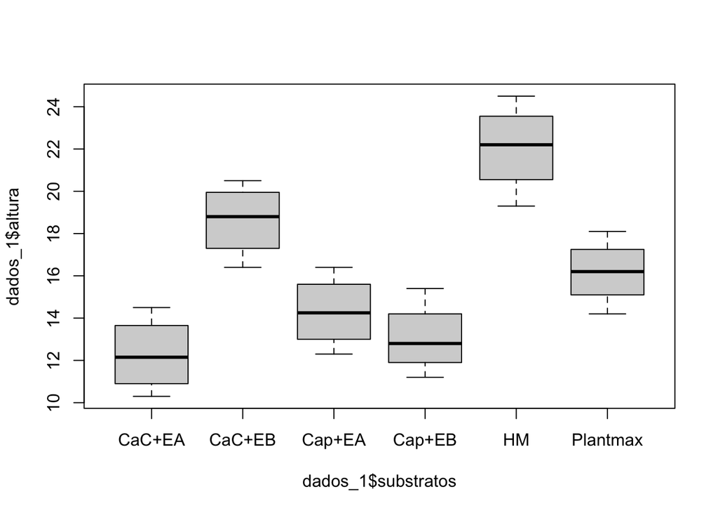

```r
# Boxplot dos valores observados em função dos tratamentos
boxplot(dados_1$altura ~ dados_1$substratos)
```

- **Testes de homogeneidade de variâncias**: Alguns testes utilizados incluem Bartlett, **Breusch-Pagan**, Levene, Samiuddin, O’Neill e Mathews, Layard, Park, White, Cochran, Hartley e Goldfeld-Quandt.

```r
# Teste de Bartlett
bartlett.test(res_3 ~ dados_1$substratos)
```

```
    Bartlett test of homogeneity of variances

data:  res_3 by dados_1$substratos
Bartlett's K-squared = 0.27704, df = 5, p-value = 0.9981
```

```r
# Teste de Breusch-Pagan
# library(lmtest)
bptest(lm_dic)
```

```
    studentized Breusch-Pagan test

data:  lm_dic
BP = 1.0259, df = 5, p-value = 0.9605
```

### Pontos discrepantes (outliers)

Embora não seja um pressuposto obrigatório, a detecção de outliers é fundamental para identificar erros de coleta ou registros anômalos. Métodos simples para essa verificação são:

- **Boxplot dos resíduos padronizados para cada tratamento**: Facilita a visualização de observações fora do padrão.

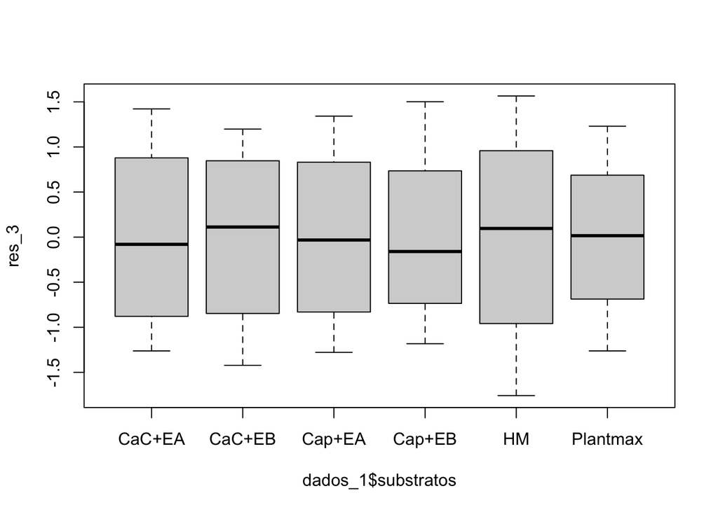

```r
# Boxplot dos resíduos padronizados
boxplot(res_3 ~ dados_1$substratos)
```

- **Gráfico dos valores estimados versus resíduos padronizados**: Observações que se afastam do intervalo $(-2, 2)$ devem ser analisadas como possíveis outliers.

### Linearidade da Variável Resposta

A linearidade entre a variável resposta e os tratamentos é um pressuposto básico para muitos modelos estatísticos. Uma verificação simples pode ser realizada através de:

- **Gráfico de dispersão (ou boxplot) dos valores observados em função dos tratamentos**: Se a variabilidade não for comum a todos os tratamentos, pode ser necessário transformar os dados para um melhor ajuste do modelo.

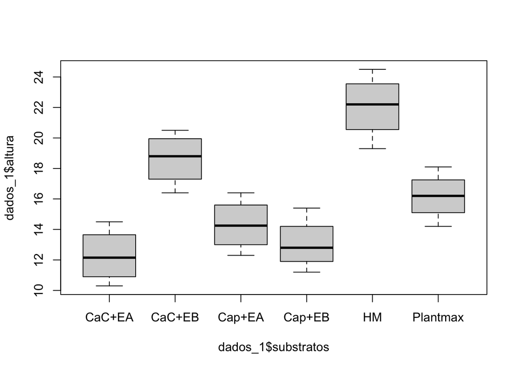

```r
# Boxplot dos valores observados em função dos tratamentos
boxplot(dados_1$altura ~ dados_1$substratos)
```

### Transformação de Variáveis

Quando os pressupostos do modelo não são atendidos, transformar os dados pode ajudar a melhorar a análise dos resíduos. A seguir, são apresentadas algumas transformações comuns:

## Transformações Específicas

- **Dados de contagem (distribuição de Poisson)**:  
  $y = \sqrt{x}$ ou $y = \sqrt{x} + 0,5$
- **Dados com distribuição assimétrica (log-normal)**:  
  $y = \log(x)$ ou $y = \log(x + c)$, onde $0 < c \leq 1$ (comumente $c = 1$ ou $1/2$.
- **Dados de proporção (binomial)**:  
  $y = \arcsin(\sqrt{x})$, também conhecido como transformação arco-seno.

### Transformações por Potência

Uma forma geral de transformação é a potência, definida como $y = x^p$:

- Quando $p = 0$, utilizamos a transformação logarítmica: $y = \log(x)$.
- Quando $p = 2$, obtemos: $y = x^2$.
- Quando $p = \frac{1}{2}$, temos: $y = \sqrt{x}$.
- Quando $p = -1$, a transformação é: $y = \frac{1}{x}$.
- Quando $p = -\frac{1}{2}$, resulta em: $y = \frac{1}{\sqrt{x}}$.

## Transformação de Box-Cox

A transformação de Box-Cox é uma técnica poderosa para estabilizar a variância e aproximar a normalidade dos resíduos. Ela é definida por:

$$y = \frac{x^p - 1}{p}, \quad \text{para } p \neq 0,$$

$$y = \log(x), \quad \text{para } p = 0.$$

O parâmetro $p$ pode ser estimado através da maximização da função:

$$L(p) = -\frac{1}{2}\log\left[ QMErro(p) \right],$$

em que $QMErro(p)$ representa o quadrado médio do erro obtido na análise de variância após a transformação de Box-Cox.

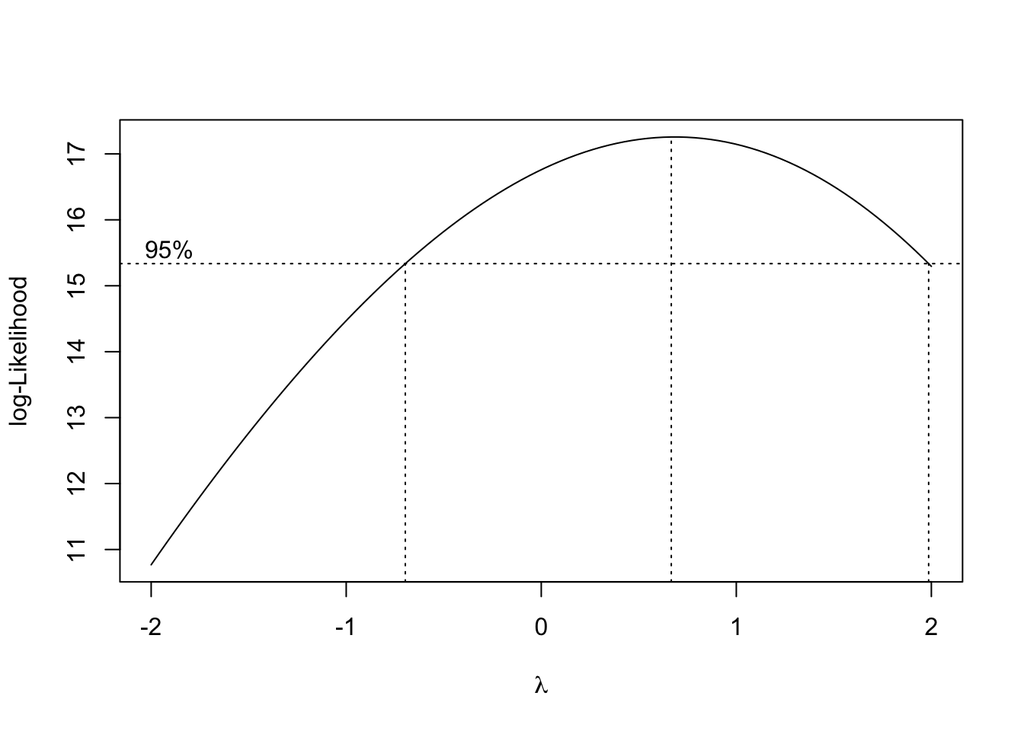

```r
# transformação boxcox
# library(MASS)
boxcox(lm_dic, lambda = seq(-2, 2, 0.1))
```

### Experimento

Arquivo com os dados: dados_4.xlsx

```r
# Lendo os dados
# dados simulados
dados_4 <- read_xlsx("dados_4.xlsx")
dados_4
```

```
# A tibble: 24 × 3
   repeticao substratos altura
       <dbl> <chr>       <dbl>
 1         1 CaC+EB       18.2
 2         2 CaC+EB       16.4
 3         3 CaC+EB       20.5
 4         4 CaC+EB       19.4
 5         1 CaC+EA       12.8
 6         2 CaC+EA       14.5
 7         3 CaC+EA       10.3
 8         4 CaC+EA       11.5
 9         1 HM           11.8
10         2 HM           19.3
# ℹ 14 more rows
```

```r
names(dados_4)
```

```
[1] "repeticao"  "substratos" "altura"
```

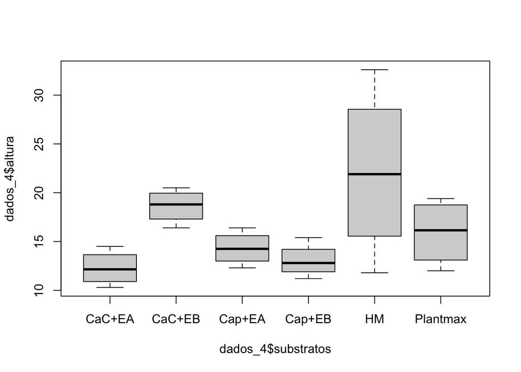

```r
# Análise gráfica da variável resposta por tratamento
boxplot(dados_4$altura ~ dados_4$substratos)
```

```r
# Ajuste do modelo
lm_dic2 <- lm(altura ~ substratos, data = dados_4)
anova(lm_dic2)
```

```
Analysis of Variance Table

Response: altura
           Df Sum Sq Mean Sq F value  Pr(>F)
substratos  5 275.83  55.167  3.2852 0.02783 *
Residuals  18 302.26  16.792
---
Signif. codes:  0 '***' 0.001 '**' 0.01 '*' 0.05 '.' 0.1 ' ' 1
```

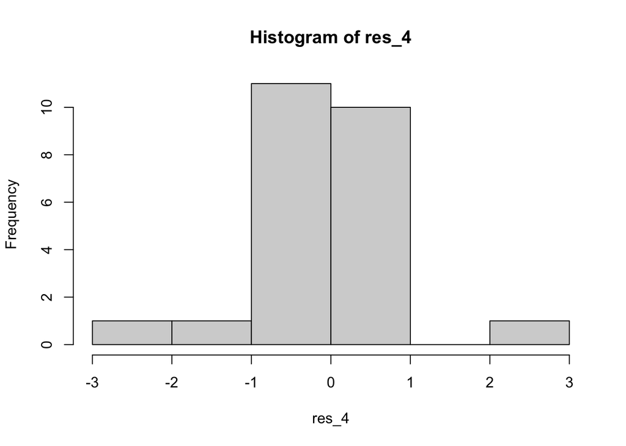

```r
# Resíduo padronizado
res_4 <- rstandard(lm_dic2)

# histograma dos resíduos
hist(res_4)
```

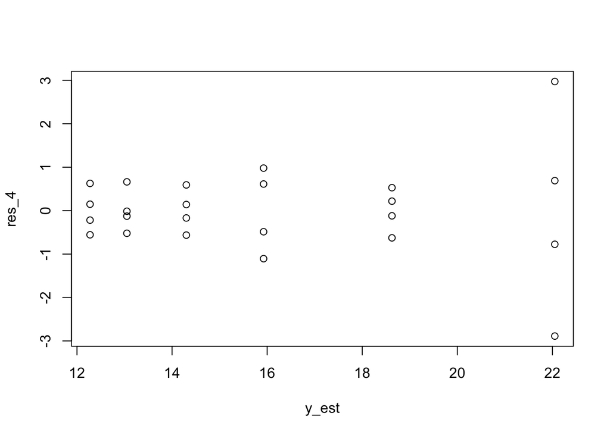

```r
# Gráfico dos valores estimados versus resíduos padronizados
y_est <- fitted(lm_dic2)
plot(y_est, res_4) # os pontos estão entre (-2, 2)?
```

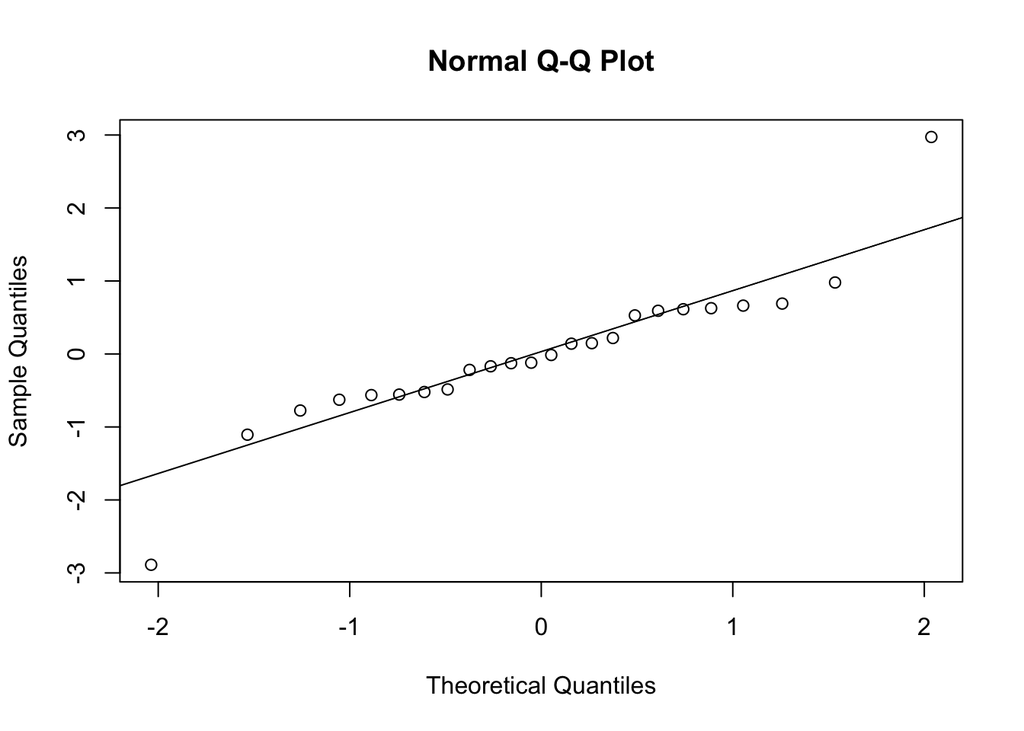

```r
# qq-plot
qqnorm(res_4)
qqline(res_4)
```

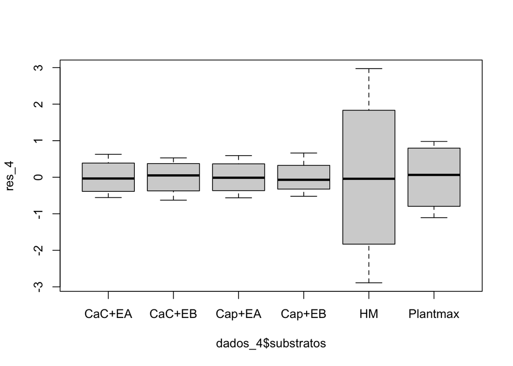

```r
# box plot dos resíduos por tratamento
boxplot(res_4 ~ dados_4$substratos)
```

```r
# Teste de Shapiro-Wilk
shapiro.test(res_4)
```

```
    Shapiro-Wilk normality test

data:  res_4
W = 0.88827, p-value = 0.01224
```

```r
# Teste de Kolmogorov-Smirnov
ks.test(res_4, "pnorm", mean = 0, sd = 1)
```

```
    Exact one-sample Kolmogorov-Smirnov test

data:  res_4
D = 0.16165, p-value = 0.5063
alternative hypothesis: two-sided
```

```r
# teste de homogeneidade de variâncias
bartlett.test(res_4 ~ dados_4$substratos)
```

```
    Bartlett test of homogeneity of variances

data:  res_4 by dados_4$substratos
Bartlett's K-squared = 14.889, df = 5, p-value = 0.01085
```

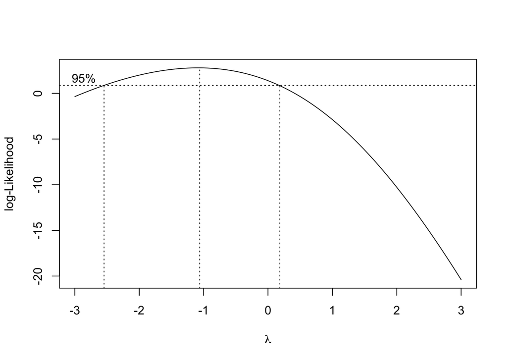

```r
# transformação boxcox
boxcox(lm_dic2, lambda = seq(-3, 3, 0.1))
```

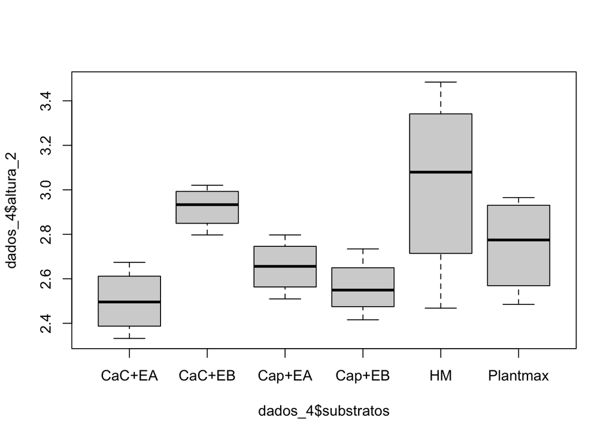

```r
dados_4$altura_2 <- log(dados_4$altura)
boxplot(dados_4$altura_2 ~ dados_4$substratos)
```

```r
lm_dic3 <- lm(altura_2 ~ substratos, data = dados_4)
anova(lm_dic3)
```

```
Analysis of Variance Table

Response: altura_2
           Df  Sum Sq  Mean Sq F value  Pr(>F)
substratos  5 0.84929 0.169858  3.4324 0.02365 *
Residuals  18 0.89075 0.049486
---
Signif. codes:  0 '***' 0.001 '**' 0.01 '*' 0.05 '.' 0.1 ' ' 1
```

```r
res_5 <- rstandard(lm_dic3)
bartlett.test(res_5 ~ dados_4$substratos)
```

```
    Bartlett test of homogeneity of variances

data:  res_5 by dados_4$substratos
Bartlett's K-squared = 9.2157, df = 5, p-value = 0.1008
```

```r
shapiro.test(res_5)
```

```
    Shapiro-Wilk normality test

data:  res_5
W = 0.94999, p-value = 0.2708
```

```r
# Anova e Tukey
crd(treat = dados_4$substratos,
    resp = dados_4$altura_2,
    mcomp = "tukey")
```

```
------------------------------------------------------------------------
Analysis of Variance Table
------------------------------------------------------------------------
           DF      SS       MS     Fc    Pr>Fc
Treatament  5 0.84929 0.169858 3.4324 0.023648
Residuals  18 0.89075 0.049486
Total      23 1.74004
------------------------------------------------------------------------
CV = 8.13 %

------------------------------------------------------------------------
Shapiro-Wilk normality test
p-value:  0.2708366
According to Shapiro-Wilk normality test at 5% of significance, residuals can be considered normal.
------------------------------------------------------------------------

------------------------------------------------------------------------
Homogeneity of variances test
p-value:  0.1007622
According to the test of bartlett at 5% of significance, residuals can be considered homocedastic.
------------------------------------------------------------------------

Tukey's test
------------------------------------------------------------------------
Groups Treatments Means
a    HM      3.027798
ab   CaC+EB      2.9211
ab   Plantmax    2.749833
ab   Cap+EA      2.654726
ab   Cap+EB      2.562232
 b   CaC+EA      2.499521
------------------------------------------------------------------------
```

```r
# Scott-Knott
crd(treat = dados_4$substratos,
    resp = dados_4$altura_2,
    mcomp = "sk")
```

```
------------------------------------------------------------------------
Analysis of Variance Table
------------------------------------------------------------------------
           DF      SS       MS     Fc    Pr>Fc
Treatament  5 0.84929 0.169858 3.4324 0.023648
Residuals  18 0.89075 0.049486
Total      23 1.74004
------------------------------------------------------------------------
CV = 8.13 %

------------------------------------------------------------------------
Shapiro-Wilk normality test
p-value:  0.2708366
According to Shapiro-Wilk normality test at 5% of significance, residuals can be considered normal.
------------------------------------------------------------------------

------------------------------------------------------------------------
Homogeneity of variances test
p-value:  0.1007622
According to the test of bartlett at 5% of significance, residuals can be considered homocedastic.
------------------------------------------------------------------------

Scott-Knott test
------------------------------------------------------------------------
  Groups Treatments    Means
1      a         HM 3.027798
2      a     CaC+EB 2.921100
3      b   Plantmax 2.749833
4      b     Cap+EA 2.654726
5      b     Cap+EB 2.562232
6      b     CaC+EA 2.499521
------------------------------------------------------------------------
```

[@profjulianobortolini](https://instagram.com/profjulianobortolini) www.julianobortolini.com.br [linkedin](https://linkedin.com/in/julianobortolini) [github](https://github.com/julianobortolini) [lattes](http://lattes.cnpq.br/6210909768845403)